# SC Shellfish Mariculture Governance Network

## By Coalition

```r
by_coalition <- results %>%
  group_by(Coalition = coalition) %>%
  summarise(
    n                  = n(),
    `Mean Betweenness` = round(mean(betweenness), 4),
    `Mean Eigenvector` = round(mean(eigenvector), 4),
    `Mean Gatekeeper`  = round(mean(Gatekeeper), 2),
    `Mean Liaison`     = round(mean(Liaison), 2),
    .groups = "drop"
  ) %>%
  arrange(desc(`Mean Betweenness`))

datatable(by_coalition, rownames = FALSE,
          options = list(dom = "t", pageLength = 10),
          class = "stripe compact") %>%
  formatStyle("Coalition",
    backgroundColor = styleEqual(
      c("regulatory-cautious","neutral","pro-expansion","conservation"),
      c("#FADBD8","#D6EAF8","#D5F5E3","#E8DAEF")
    ))
```

| Coalition | n | Mean Betweenness | Mean Eigenvector | Mean Gatekeeper | Mean Liaison |
| --- | --- | --- | --- | --- | --- |
| regulatory-cautious | 26 | 0.0208 | 0.173 | 3.08 | 8.19 |
| neutral | 30 | 0.0206 | 0.1688 | 5.9 | 1.87 |
| pro-expansion | 42 | 0.013 | 0.1776 | 3.71 | 6.21 |
| conservation | 5 | 0.0018 | 0.0471 | 0 | 0 |

## Betweenness Distribution

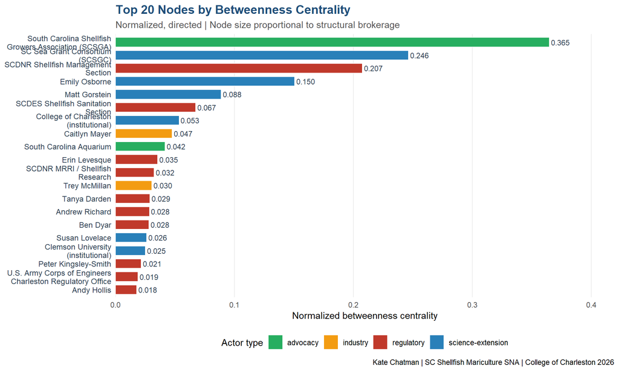

```r
top20 <- results %>%
  head(20) %>%
  mutate(
    name_short = str_wrap(name, 30),
    bar_color  = actor_colors[actor_type]
  )

ggplot(top20, aes(x = reorder(name_short, betweenness), y = betweenness,
                  fill = actor_type)) +
  geom_col(width = 0.7, color = "white", linewidth = 0.3) +
  geom_text(aes(label = sprintf("%.3f", betweenness)),
            hjust = -0.1, size = 3, color = "#2C3E50") +
  scale_fill_manual(values = actor_colors, name = "Actor type") +
  scale_y_continuous(expand = expansion(mult = c(0, 0.15))) +
  coord_flip() +
  labs(
    title    = "Top 20 Nodes by Betweenness Centrality",
    subtitle = "Normalized, directed | Node size proportional to structural brokerage",
    x = NULL, y = "Normalized betweenness centrality",
    caption  = "Kate Chatman | SC Shellfish Mariculture SNA | College of Charleston 2026"
  ) +
  theme_minimal(base_family = "Arial") +
  theme(
    plot.title    = element_text(face = "bold", size = 14, color = "#1F4E79"),
    plot.subtitle = element_text(size = 11, color = "#555555"),
    axis.text.y   = element_text(size = 9, color = "#2C3E50"),
    legend.position = "bottom",
    panel.grid.major.y = element_blank(),
    panel.grid.minor   = element_blank()
  )
```

## Data & Methods Notes

Edge coding rules: Institutional authority edges are held by institutional nodes (not named staff). Individual collaboration and information edges are held by named individuals when those individuals exercise professional judgment. Historical nodes retain all edges established during their tenure to model institutional path dependency.

Relationship types: regulatory_authority (burden-generating, unidirectional) · regulatory_consultation · collaboration · information · commercial_supply · funding

Evidence tiers: Tier 1 = published document or official record · Tier 2 = documented professional knowledge · Tier 3 = inferred from institutional succession

Centrality & Brokerage: Betweenness normalized 0–1 across directed graph. Eigenvector computed from largest eigenvalue of directed adjacency matrix. Brokerage values generated via Gould-Fernandez raw non-overlapping group interval vectors using the sna package matrix engines.

Historical nodes: Susan Lovelace (SCSGC ED, departed Oct 2025), Peter Kingsley-Smith (SCDNR MRRI, departed May 2026), Sarah Pedigo (SCSGC, departed ~2024), Graham Gaines, Nancy Hadley. Retained to model institutional lock-in; displayed with reduced opacity and dashed borders.

Data sources: SC Sea Grant Consortium Aquaculture Permitting Guide (2021) · SCDNR mariculture contacts and org chart · SCDES Shellfish Sanitation Section · USACE NWP 48 documentation · SCSGC annual reports FY22-24 · January 2024 SCSGC aquaculture working group survey · Cribbs et al. (2024) social carrying capacity · Estuaries & Coasts (2025)

Kate Chatman · MPA/EVSS Candidate · College of Charleston · SC Sea Grant Consortium Graduate Assistant · May 2026

*Kate Chatman · MPA/EVSS Candidate · College of Charleston · SC Sea Grant Consortium Graduate Assistant · (c)May 2026*